# Biodiversity in National Parks

Cindy Te, Jessica Zhang, Shirley Yao, Victoria Limwanich

11/19/2021

## Introduction

The purpose and importance of this project is to learn more about the trends of biodiversity. As humans are quickly exceeding one of the nine planetary boundaries, biosphere integrity (especially genetic biodiversity), it is urgent for us find information, analyze it, and understand the trends of biodiversity to develop solutions to prevent biodiversity from further reducing and to help mitigate its negative impacts.

## Summary Information

In a study containing 119248 species across 56 national parks, there are 14 different categories of species that contain a total of 35826 different types of species. Of these species, there are a total of 10768 rare species, 374 of which are endangered species.

## Aggregate Table

The table groups each national parks’ observations together to summarize the total number of species in each park, and then calculate the percentage of species that are of concern, threatened, or endangered. The table shows that Petrified Forest National Park has the highest percentage (9.26%) of species that are of concern, threatened, or endangered, while Gates Of The Arctic National Park and Preserve has the lowest percentage (1.55%) of species that are of concern, threatened, or endangered. This gives insight on which national parks are at a higher risk of biodiversity loss.

| Park | Total of Species | Percent of Species of Concern, Threatened, or Endangered |
| --- | --- | --- |
| Petrified Forest National Park | 853 | 9.26% |
| Channel Islands National Park | 1885 | 7.21% |
| Mesa Verde National Park | 1243 | 7.08% |
| Arches National Park | 1048 | 6.97% |
| Dry Tortugas National Park | 848 | 6.72% |
| Carlsbad Caverns National Park | 1536 | 6.51% |
| Canyonlands National Park | 1223 | 6.46% |
| Great Sand Dunes National Park and Preserve | 952 | 5.99% |
| Big Bend National Park | 2269 | 5.82% |
| Capitol Reef National Park | 1566 | 5.81% |
| Black Canyon of the Gunnison National Park | 1106 | 5.79% |
| Bryce Canyon National Park | 1286 | 5.60% |
| Zion National Park | 1796 | 5.40% |
| Pinnacles National Park | 1416 | 5.23% |
| Saguaro National Park | 1834 | 5.13% |
| Guadalupe Mountains National Park | 1746 | 4.98% |
| Grand Canyon National Park | 2622 | 4.92% |
| Death Valley National Park | 4439 | 4.89% |
| Wind Cave National Park | 1395 | 4.80% |
| Badlands National Park | 1389 | 4.68% |
| Joshua Tree National Park | 2294 | 4.62% |
| Theodore Roosevelt National Park | 1165 | 4.55% |
| Lassen Volcanic National Park | 1797 | 4.51% |
| Everglades National Park | 2084 | 4.46% |
| Isle Royale National Park | 1397 | 4.44% |
| Kenai Fjords National Park | 1057 | 4.35% |
| Yosemite National Park | 2088 | 4.31% |
| Olympic National Park | 1948 | 4.11% |
| Sequoia and Kings Canyon National Parks | 1995 | 4.11% |
| Acadia National Park | 1709 | 4.04% |
| Grand Teton National Park | 2030 | 3.99% |
| Voyageurs National Park | 1453 | 3.79% |
| Great Basin National Park | 2653 | 3.62% |
| Biscayne National Park | 1726 | 3.48% |
| Hawaii Volcanoes National Park | 3298 | 3.46% |
| Hot Springs National Park | 1950 | 3.44% |
| Katmai National Park and Preserve | 1225 | 3.18% |
| Haleakala National Park | 2580 | 3.14% |
| Mount Rainier National Park | 1743 | 3.10% |
| Glacier Bay National Park and Preserve | 1957 | 3.01% |
| Glacier National Park | 2556 | 3.01% |
| Cuyahoga Valley National Park | 1941 | 2.78% |
| Mammoth Cave National Park | 2499 | 2.68% |
| Wrangell - St Elias National Park and Preserve | 1796 | 2.67% |
| Redwood National Park | 6310 | 2.47% |
| Denali National Park and Preserve | 1320 | 2.35% |
| North Cascades National Park | 3363 | 2.26% |
| Kobuk Valley National Park | 1025 | 2.24% |
| Yellowstone National Park | 3966 | 2.22% |
| Rocky Mountain National Park | 3152 | 2.19% |
| Lake Clark National Park and Preserve | 2007 | 2.04% |
| Crater Lake National Park | 3760 | 1.99% |
| Great Smoky Mountains National Park | 6623 | 1.86% |
| Congaree National Park | 2321 | 1.81% |
| Shenandoah National Park | 4655 | 1.80% |
| Gates Of The Arctic National Park and Preserve | 1353 | 1.55% |

## Chart 1

[output not shown]

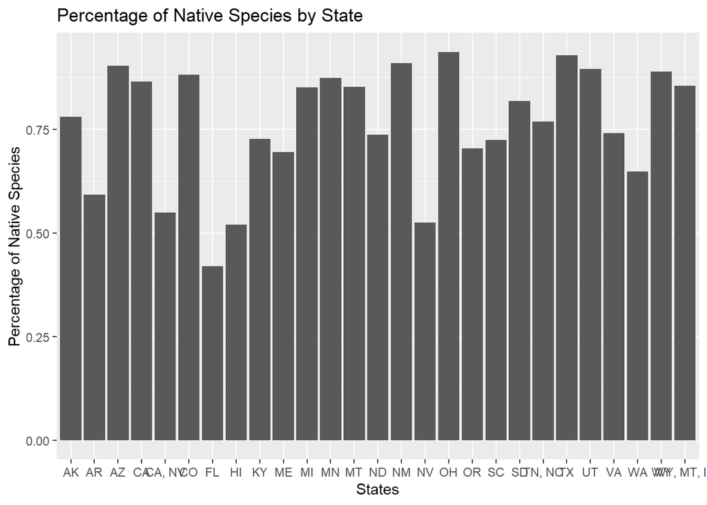

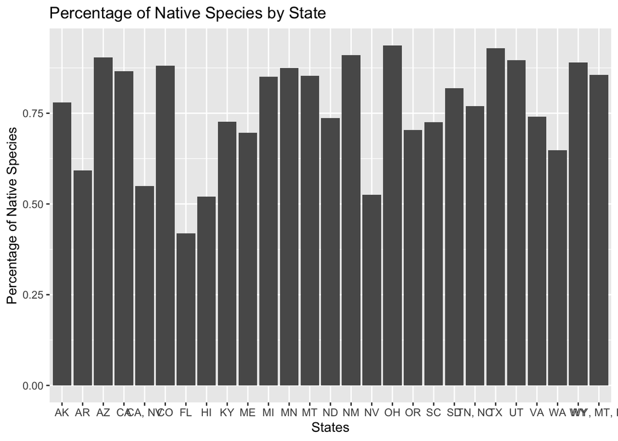

## Chart 2

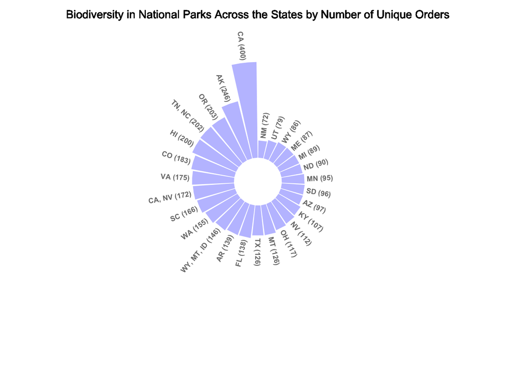

This chart gives a visualization of the level of biodiversity in different national parks across the United States. It helps give a comparison and ranking of the state of biodiversity across different states/regions. This chart was made using the number of unique orders (Carnivora, Rodentia, etc.) in each reported National Park, and then grouping them together by state. From this chart, we can see that the distribution of biodiversity is varied and doesn’t have much pattern. The leading state by a large margin, California, has a reported 400 unique orders, and the reported state with the least biodiversity, New Mexico, has 72 unique orders in its national parks. This gives us insight into the amount and state of national parks in the different regions, including the amount of reported orders.

## Chart 3

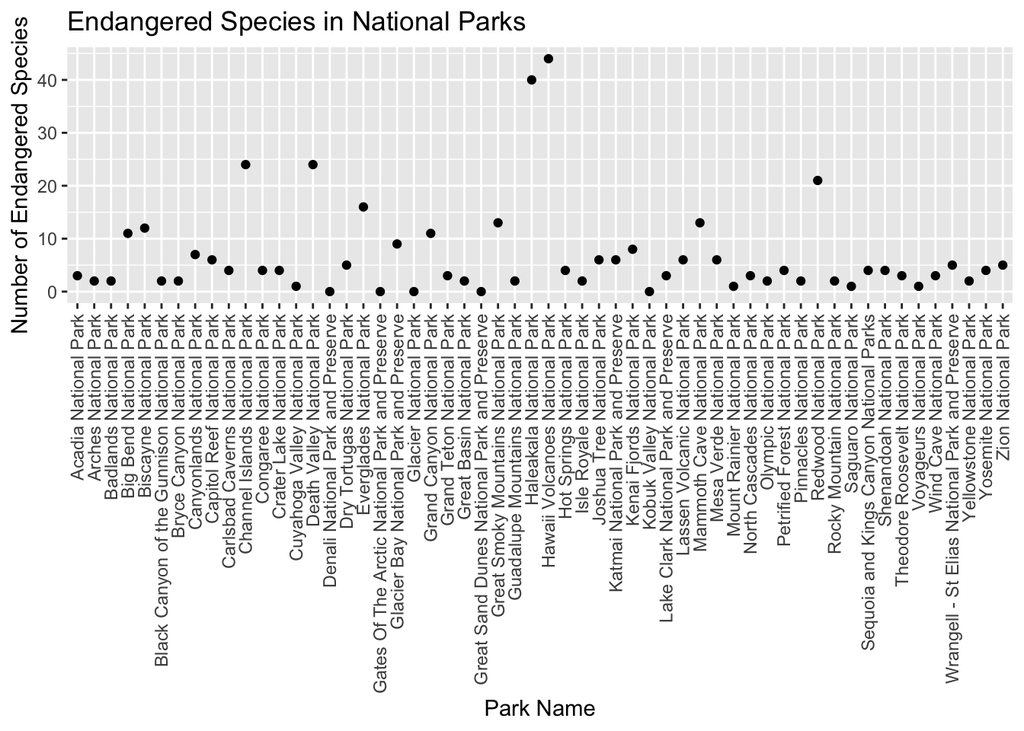

The scatter plot visualizes the number of endangered species in every national park in the U.S., in which we can see that Hawaii Volcanoes National Park has the highest number of endangered species, whereas most of the other national parks’ endangered species number range between 0-10. By creating the plot with clear visualization, we are motivated to ask questions that deepens our understanding of conservation and biodiversity, such as why are certain national parks have more endangered species than others? What are the implications in terms of maintaining biodiversity in the context of places relatively free from human intervention such as national parks?